# Site Occupancy Lapin

08/08

## 1 Intallation des packages

```r
library(dplyr);library(ggplot2);library(sf);library(unmarked)
theme_set(theme_light(base_size = 16))
```

## 2 Importation des bases de donnees

```r
Total <- sf::st_read(paste0(wd$data, "derived/Total.shp"),
                     options = "ENCODING=UTF8")
```

```
## options:        ENCODING=UTF8
```

```r
Total <- Total%>%
  transform_Total()

VariablesSite <- sf::st_read(paste0(wd$data, "derived/VariablesSite.shp"),
                             options = "ENCODING=UTF8")
```

```
## options:        ENCODING=UTF8
```

```r
VariablesSite <- VariablesSite%>%
  transform_VarSites()
```

```r
Lapins <- Total %>%
  sf::st_join(VariablesSite) %>%
  dplyr::filter(cd_nom == 61714,
                technique_observation == "Vu",
                date >= as.Date("2005-01-01")) %>%
  # select(-c(insee_dept, lib_dept, lib_dept, FID, surf, CD_SIG)) %>%
  dplyr::select(-nom_valide, -nom_vernaculaire, -ordre, -technique_observation) %>%
  dplyr::mutate(year = lubridate::year(date))
```

## 3 Creation de la base de donnee Detection - Non Detection

```r
detection_df <- Lapins %>%
  sf::st_drop_geometry() %>%
  dplyr::mutate(annee = lubridate::year(date)) %>%
  dplyr::select(Code_10km, annee) %>%
  dplyr::count(Code_10km, annee) %>%
  tidyr::complete(Code_10km,
                  annee = tidyr::full_seq(annee, 1),
                  fill = list(n = 0)) %>%
  tidyr::pivot_wider(names_from = annee,
                     values_from = n) %>%
  dplyr::arrange(Code_10km) %>%
  dplyr::filter(!is.na(Code_10km))

detection_df[,-1] <- ifelse(detection_df[,-1]>0, 1, 0)

noms <- detection_df$Code_10km
detection_matrice <- as.matrix(detection_df[, -1])
rownames(detection_matrice) <- noms
```

## 4 Covariables de site

```r
site_info <- VariablesSite %>%
  sf::st_drop_geometry() %>%
  dplyr::arrange(Code_10km)

noms <- site_info$Code_10km
rownames(site_info) <- noms

site_info <- site_info %>%
  dplyr::select(-Code_10km) %>%
  dplyr::rename(Dnst_Cultures = `Dnst_Cultures `)%>%
  dplyr::mutate(across(where(is.numeric),
                       scale))
```

## 5 Implementation du Model

Mise sous format pour la modelisation

```r
umf <- unmarked::unmarkedFrameOccu(y = detection_matrice,
                                   siteCovs = site_info
                                   )
```

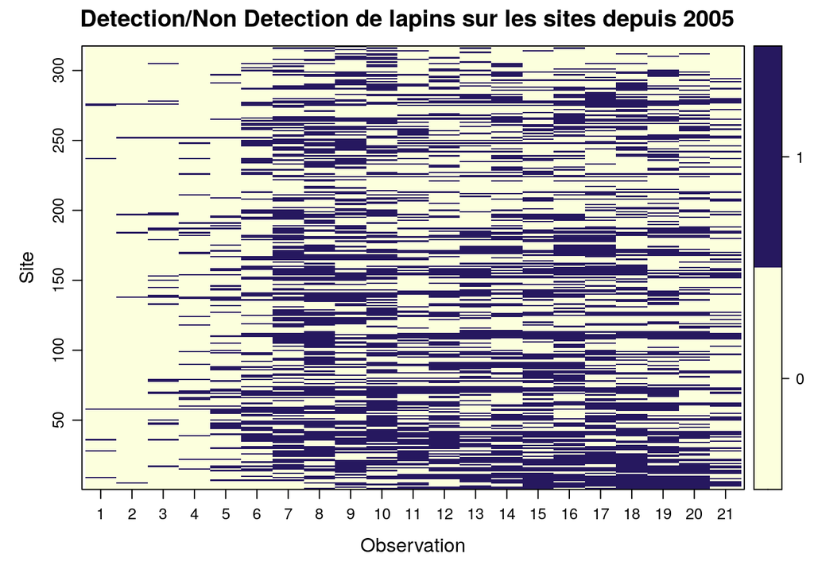

```r
unmarked::plot(umf, main="Detection/Non Detection de lapins sur les sites depuis 2005")
```

On retirera ensuite les annees [2005 - 2009]. J’ai longtemps hesite entre garder 2009, ou 2025. Les 2 ont peu de donnees par rapport aux reste (2025 ca je n’ai pas l’annee entiere, et 2009 car c’est tôt). Les deux participerait a augementer la probabilite de detection.

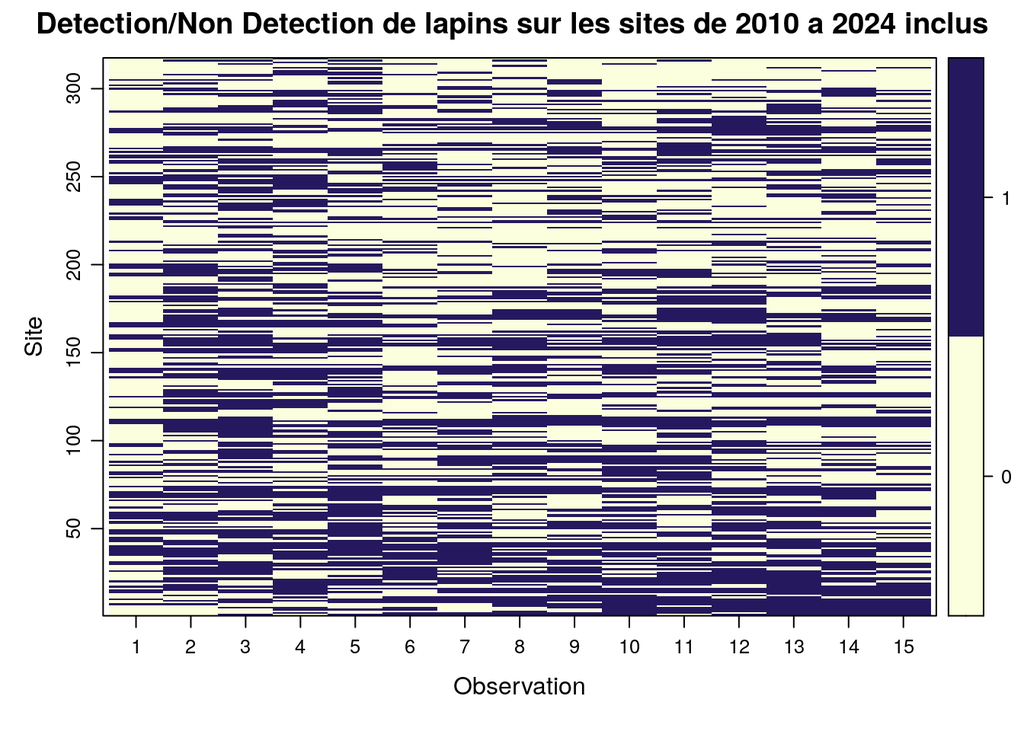

```r
Lapins <- Total %>%
  sf::st_join(VariablesSite) %>%
  dplyr::filter(cd_nom == 61714,
                technique_observation == "Vu",
                date >= as.Date("2010-01-01"),
                date < as.Date("2025-01-01")) %>%
  # select(-c(insee_dept, lib_dept, lib_dept, FID, surf, CD_SIG)) %>%
  dplyr::select(-nom_valide, -nom_vernaculaire, -ordre, -technique_observation) %>%
  dplyr::mutate(year = lubridate::year(date))

detection_df <- Lapins %>%
  sf::st_drop_geometry() %>%
  dplyr::mutate(annee = lubridate::year(date)) %>%
  dplyr::select(Code_10km, annee) %>%
  dplyr::count(Code_10km, annee) %>%
  tidyr::complete(Code_10km,
                  annee = tidyr::full_seq(annee, 1),
                  fill = list(n = 0)) %>%
  tidyr::pivot_wider(names_from = annee,
                     values_from = n) %>%
  dplyr::arrange(Code_10km) %>%
  dplyr::filter(!is.na(Code_10km))

detection_df[,-1] <- ifelse(detection_df[,-1]>0, 1, 0)

noms <- detection_df$Code_10km
detection_matrice <- as.matrix(detection_df[, -1])
rownames(detection_matrice) <- noms

umf <- unmarked::unmarkedFrameOccu(y = detection_matrice,
                                   siteCovs = site_info
                                   )

unmarked::plot(umf, main="Detection/Non Detection de lapins sur les sites de 2010 a 2024 inclus")
```

```r
summary(umf)
```

```
## unmarkedFrame Object
##
## 317 sites
## Maximum number of observations per site: 15
## Mean number of observations per site: 15
## Sites with at least one detection: 307
##
## Tabulation of y observations:
##    0    1
## 2577 2178
##
## Site-level covariates:
##        Ind_Diversite.V1             Dnst_Cultures.V1         Dist_EcotoneArbore.V1
##  Min.   :-2.865708445210000   Min.   :-2.78214762389e+00   Min.   :-1.177548563760
##  1st Qu.:-0.679780380756000   1st Qu.:-6.39147940409e-01   1st Qu.:-0.538861888256
##  Median :-0.103681984768000   Median : 6.52166412662e-02   Median :-0.234385970959
##  Mean   : 0.000000000000001   Mean   : 2.00000000000e-16   Mean   : 0.000000000000
##  3rd Qu.: 0.590728352478000   3rd Qu.: 6.59758341030e-01   3rd Qu.: 0.149328232852
##  Max.   : 3.387273586330000   Max.   : 2.36743641082e+00   Max.   : 7.826110849440
##
##      Dist_Littoral.V1             Dist_Eau.V1                                    Famille_paysage
##  Min.   :-1.070027865720   Min.   :-2.486983274260   Paysage cultive a ragosses          :90
##  1st Qu.:-0.915859784196   1st Qu.:-0.653550370660   Paysage boise et de bosquets        :57
##  Median :-0.266683896501   Median :-0.230018369783   Paysage cultive avec talus          :52
##  Mean   : 0.000000000000   Mean   : 0.000000000000   Paysage de bocage a maille elargie  :41
##  3rd Qu.: 0.699371185739   3rd Qu.: 0.584178367602   Paysage de bocage dense sur collines:34
##  Max.   : 2.957617628370   Max.   : 6.943084217390   Paysage de littoral urbanise        :27
##                                                      (Other)                             :16
##                         Nom_paysage         air_km2.V1                  X_10km.V1
##  Reliefs des Landes de Lanvaux: 36   Min.   :-3.199398376490   Min.   :-1.91668816575e+00
##  Plateau de Penthievre        : 20   1st Qu.: 0.131669308234   1st Qu.:-7.91009617370e-01
##  Bassin de Pontivy-Loudeac    : 18   Median : 0.522356248052   Median : 1.43352452421e-03
##  Armor morbihannais           : 17   Mean   : 0.000000000000   Mean   : 1.00000000000e-16
##  Bassin de Rennes             : 17   3rd Qu.: 0.522356248055   3rd Qu.: 8.11993642375e-01
##  Cornouaille interieure       : 16   Max.   : 0.522356248061   Max.   : 1.82993231695e+00
##  (Other)                      :193
##           Y_10km.V1
##  Min.   :-2.36529227433e+00
##  1st Qu.:-7.80490736624e-01
##  Median : 1.54633653399e-02
##  Mean   : 1.07000000000e-14
##  3rd Qu.: 8.34068493645e-01
##  Max.   : 1.96182815611e+00
##
```

## 6 Modeles d’occupation a plusieurs saisons

Au sein d’une saison, les lapins sont soit present soit absent mais ne changent pas. Entre les saisons, les lapins peuvent coloniser un site (ie: il etiaent pas là avant et mtn ils le sont), ou disparaitre = extinction locale. C’est une chaine de Marcov.

Ici on suppose, qu’il n’y a pas de faux positif.

On a - psi $\psi$ : prob occupation - p $p$ : prob detection - gamma $\gamma$ : prob de colonisation - epsilon $\epsilon$ : prob d’extinction

```r
quali_periodes_matrice <-
  matrix(c('2010 - 2014','2015 - 2019','2020 - 2024'),
         nrow = nrow(detection_df),
         ncol = 3,
         byrow = TRUE)

quanti_periodes_matrice <- matrix(
  1:3,
  nrow=nrow(detection_df),
  ncol=3,
  byrow=TRUE)
```

```r
site_covs_periodes <- list(
  quanti_periodes = quanti_periodes_matrice,
  quali_periodes = quali_periodes_matrice
)
```

On a les periodes sous la forme qualitiative et quantitative, pour tester les 2 facons.

```r
detections_per_year = colSums(detection_matrice)

print(detections_per_year)
```

```
## 2010 2011 2012 2013 2014 2015 2016 2017 2018 2019 2020 2021 2022 2023 2024
##   95  165  179  158  166  123  140  134  147  143  158  153  152  143  122
```

On a bcp de detections sur toutes les annees en vrai..

```r
umf <- unmarkedMultFrame(
  y = detection_matrice,
  siteCovs = site_info,
  yearlySiteCovs = site_covs_periodes,
  numPrimary = 3
)
fm <- unmarked::colext(
  psiformula = ~ Dnst_Cultures + Dist_Littoral + Dist_EcotoneArbore,
  pformula = ~ 1,
  gammaformula =  ~ 1,
  epsilonformula = ~ 1,
  data = umf,
  control = list(trace = 1),
  se = TRUE)
```

Les coefficients transform?:

```r
plogis(coef(fm)[1]);plogis(coef(fm)[2]);plogis(coef(fm)[3]);plogis(coef(fm)[4])
```

```
##  psi(Int)
## 0.9165003
```

```
## psi(Dnst_Cultures)
##          0.3766443
```

```
## psi(Dist_Littoral)
##          0.4141349
```

```
## psi(Dist_EcotoneArbore)
##               0.5057659
```

```r
plogis(coef(fm)[5]);plogis(coef(fm)[6])
```

```
##  col(Int)
## 0.5437717
```

```
##  ext(Int)
## 0.1246077
```

```r
plogis(coef(fm)[7])
```

```
##    p(Int)
## 0.5374333
```

```r
fm0 <- colext(
  psiformula = ~ 1,     # initial occupancy
  gammaformula =  ~ 1,  # colonization
  epsilonformula = ~ 1, # extinction
  pformula = ~ 1,  # detection
  data = umf, # data
  control = list(trace = 1)
  )
summary(fm0)
```

```
##
## Call:
## colext(psiformula = ~1, gammaformula = ~1, epsilonformula = ~1,
##     pformula = ~1, data = umf, control = list(trace = 1))
##
## Initial (logit-scale):
##  Estimate    SE    z  P(>|z|)
##      2.17 0.202 10.7 6.15e-27
##
## Colonization (logit-scale):
##  Estimate    SE     z P(>|z|)
##     0.212 0.227 0.934    0.35
##
## Extinction (logit-scale):
##  Estimate    SE     z  P(>|z|)
##     -1.94 0.144 -13.4 3.38e-41
##
## Detection (logit-scale):
##  Estimate     SE    z  P(>|z|)
##     0.154 0.0337 4.56 5.17e-06
##
## AIC: 6240.559
## Number of sites: 317
```

colonisation

```r
unmarked::backTransform(fm0, type="col")
```

```
## Backtransformed linear combination(s) of Colonization estimate(s)
##
##  Estimate     SE LinComb (Intercept)
##     0.553 0.0561   0.212           1
##
## Transformation: logistic
```

Il a ici une probabilite de $0,55$ de coloniser un site ou le lapin n’est pas present.

```r
unmarked::backTransform(fm0, type="ext")
```

```
## Backtransformed linear combination(s) of Extinction estimate(s)
##
##  Estimate     SE LinComb (Intercept)
##     0.126 0.0159   -1.94           1
##
## Transformation: logistic
```

```r
unmarked::backTransform(fm0, type="psi")
```

```
## Backtransformed linear combination(s) of Initial estimate(s)
##
##  Estimate     SE LinComb (Intercept)
##     0.897 0.0186    2.17           1
##
## Transformation: logistic
```

```r
unmarked::backTransform(fm0, type="det")
```

```
## Backtransformed linear combination(s) of Detection estimate(s)
##
##  Estimate      SE LinComb (Intercept)
##     0.538 0.00838   0.154           1
##
## Transformation: logistic
```

On essaye plusieurs sans la variance, puis selon l’AIC, on calcule l’AIC a la fin avec le modele qu’on a choisi.

```r
for(i in 1:length(coef(fm0))){
  print(plogis(coef(fm0)[i]))
}
```

```
##  psi(Int)
## 0.8973592
##  col(Int)
## 0.5527701
## ext(Int)
## 0.125708
##    p(Int)
## 0.5383582
```

Maintenant, on ajoute les variables de sites, et on regarde pour l’instant uniquement l’AIC, afin de faire un tri rapide. On fait une elimination forwards manuelle.

```r
fm0 <- unmarked::colext(
  psiformula = ~ 1,     # initial occupancy
  gammaformula =  ~ 1,  # colonization
  epsilonformula = ~ 1, # extinction
  pformula = ~ 1,  # detection
  data = umf, # data
  control = list(trace = 1),
  se = FALSE)
fm1 <- unmarked::colext(
  psiformula = ~ Y_10km,     # initial occupancy
  gammaformula =  ~ 1,  # colonization
  epsilonformula = ~ 1, # extinction
  pformula = ~ 1,  # detection
  data = umf, # data
  control = list(trace = 1),
  se = FALSE)
fm2 <- unmarked::colext(
  psiformula = ~ X_10km,     # initial occupancy
  gammaformula =  ~ 1,  # colonization
  epsilonformula = ~ 1, # extinction
  pformula = ~ 1,  # detection
  data = umf, # data
  control = list(trace = 1),
  se = FALSE)
fm3 <- unmarked::colext(
  psiformula = ~ Dist_Eau,     # initial occupancy
  gammaformula =  ~ 1,  # colonization
  epsilonformula = ~ 1, # extinction
  pformula = ~ 1,  # detection
  data = umf, # data
  control = list(trace = 1),
  se = FALSE)
fm4 <- unmarked::colext(
  psiformula = ~ Dist_Littoral,     # initial occupancy
  gammaformula =  ~ 1,  # colonization
  epsilonformula = ~ 1, # extinction
  pformula = ~ 1,  # detection
  data = umf, # data
  control = list(trace = 1),
  se = FALSE)
fm5 <- unmarked::colext(
  psiformula = ~ Dist_EcotoneArbore,     # initial occupancy
  gammaformula =  ~ 1,  # colonization
  epsilonformula = ~ 1, # extinction
  pformula = ~ 1,  # detection
  data = umf, # data
  control = list(trace = 1),
  se = FALSE)
fm6 <- unmarked::colext(
  psiformula = ~ Dnst_Cultures,     # initial occupancy
  gammaformula =  ~ 1,  # colonization
  epsilonformula = ~ 1, # extinction
  pformula = ~ 1,  # detection
  data = umf, # data
  control = list(trace = 1),
  se = FALSE)
fm7 <- unmarked::colext(
  psiformula = ~ Ind_Diversite,     # initial occupancy
  gammaformula =  ~ 1,  # colonization
  epsilonformula = ~ 1, # extinction
  pformula = ~ 1,  # detection
  data = umf, # data
  control = list(trace = 1),
  se = FALSE)
fmList <- unmarked::fitList(fm0, fm1, fm2, fm3, fm4, fm5, fm6, fm7)
```

```
## Your list was unnamed, so model names were added automatically
```

```r
unmarked::modSel(fmList)
```

```
## Hessian is singular.
## Hessian is singular.
## Hessian is singular.
## Hessian is singular.
## Hessian is singular.
## Hessian is singular.
## Hessian is singular.
## Hessian is singular.
```

```
##     nPars     AIC delta AICwt cumltvWt
## fm6     5 6236.03  0.00 0.398     0.40
## fm4     5 6237.01  0.98 0.244     0.64
## fm2     5 6237.24  1.21 0.218     0.86
## fm7     5 6240.40  4.37 0.045     0.90
## fm0     4 6240.56  4.53 0.041     0.95
## fm1     5 6241.73  5.70 0.023     0.97
## fm3     5 6242.40  6.37 0.016     0.98
## fm5     5 6242.55  6.53 0.015     1.00
```

Ici on garde la variable de fm6 ($ \text{Dnst_Cultures} $), et on ajoute les autres.

```r
fm0 <- fm6

fm1 <- unmarked::colext(
  psiformula = ~ Dnst_Cultures + Y_10km,     # initial occupancy
  gammaformula =  ~ 1,  # colonization
  epsilonformula = ~ 1, # extinction
  pformula = ~ 1,  # detection
  data = umf, # data
  control = list(trace = 1),
  se = FALSE)
fm2 <- unmarked::colext(
  psiformula = ~ Dnst_Cultures + X_10km,     # initial occupancy
  gammaformula =  ~ 1,  # colonization
  epsilonformula = ~ 1, # extinction
  pformula = ~ 1,  # detection
  data = umf, # data
  control = list(trace = 1),
  se = FALSE)
fm3 <- unmarked::colext(
  psiformula = ~ Dnst_Cultures + Dist_Eau,     # initial occupancy
  gammaformula =  ~ 1,  # colonization
  epsilonformula = ~ 1, # extinction
  pformula = ~ 1,  # detection
  data = umf, # data
  control = list(trace = 1),
  se = FALSE)
fm4 <- unmarked::colext(
  psiformula = ~ Dnst_Cultures + Dist_Littoral,     # initial occupancy
  gammaformula =  ~ 1,  # colonization
  epsilonformula = ~ 1, # extinction
  pformula = ~ 1,  # detection
  data = umf, # data
  control = list(trace = 1),
  se = FALSE)
fm5 <- unmarked::colext(
  psiformula = ~ Dnst_Cultures + Dist_EcotoneArbore,     # initial occupancy
  gammaformula =  ~ 1,  # colonization
  epsilonformula = ~ 1, # extinction
  pformula = ~ 1,  # detection
  data = umf, # data
  control = list(trace = 1),
  se = FALSE)
fm6 <- unmarked::colext(
  psiformula = ~ Dnst_Cultures,     # initial occupancy
  gammaformula =  ~ 1,  # colonization
  epsilonformula = ~ 1, # extinction
  pformula = ~ 1,  # detection
  data = umf, # data
  control = list(trace = 1),
  se = FALSE)
fmList <- unmarked::fitList(fm0, fm1, fm3, fm4, fm5, fm6)
```

```
## Your list was unnamed, so model names were added automatically
```

```r
unmarked::modSel(fmList)
```

```
## Hessian is singular.
## Hessian is singular.
## Hessian is singular.
## Hessian is singular.
## Hessian is singular.
## Hessian is singular.
```

```
##     nPars     AIC delta AICwt cumltvWt
## fm4     6 6234.77 0.000 0.287     0.29
## fm1     6 6234.80 0.026 0.284     0.57
## fm0     5 6236.03 1.259 0.153     0.72
## fm6     5 6236.03 1.259 0.153     0.88
## fm3     6 6237.76 2.989 0.064     0.94
## fm5     6 6237.95 3.180 0.059     1.00
```

On continue ensuite avec $\text{Dnst_Cultures} + \text{Dist_Littoral}$.

```r
fm0 <- fm4

fm1 <- unmarked::colext(
  psiformula = ~ Dnst_Cultures + Dist_Littoral + Y_10km,     # initial occupancy
  gammaformula =  ~ 1,  # colonization
  epsilonformula = ~ 1, # extinction
  pformula = ~ 1,  # detection
  data = umf, # data
  control = list(trace = 1),
  se = FALSE)
fm2 <- unmarked::colext(
  psiformula = ~ Dnst_Cultures + Dist_Littoral + X_10km,     # initial occupancy
  gammaformula =  ~ 1,  # colonization
  epsilonformula = ~ 1, # extinction
  pformula = ~ 1,  # detection
  data = umf, # data
  control = list(trace = 1),
  se = FALSE)
fm3 <- unmarked::colext(
  psiformula = ~ Dnst_Cultures + Dist_Littoral + Dist_Eau,     # initial occupancy
  gammaformula =  ~ 1,  # colonization
  epsilonformula = ~ 1, # extinction
  pformula = ~ 1,  # detection
  data = umf, # data
  control = list(trace = 1),
  se = FALSE)
fm4 <- unmarked::colext(
  psiformula = ~ Dnst_Cultures + Dist_Littoral + Dist_EcotoneArbore,     # initial occupancy
  gammaformula =  ~ 1,  # colonization
  epsilonformula = ~ 1, # extinction
  pformula = ~ 1,  # detection
  data = umf, # data
  control = list(trace = 1),
  se = FALSE)
fmList <- unmarked::fitList(fm0, fm1, fm2, fm3, fm4)
```

```
## Your list was unnamed, so model names were added automatically
```

```r
unmarked::modSel(fmList)
```

```
## Hessian is singular.
## Hessian is singular.
## Hessian is singular.
## Hessian is singular.
## Hessian is singular.
```

```
##     nPars     AIC delta AICwt cumltvWt
## fm0     6 6234.77  0.00  0.34     0.34
## fm1     7 6235.67  0.90  0.22     0.56
## fm3     7 6236.28  1.51  0.16     0.73
## fm2     7 6236.47  1.70  0.15     0.87
## fm4     7 6236.76  1.99  0.13     1.00
```

Maintenant, on remarque que le modèle sans variables supplementaires est celui dont l’AIC est le plus faible, donc on peut se permettre de s’arrêter.

On regarde ce modèle avec la variance incluse:

```r
fm <- unmarked::colext(
  psiformula = ~ Dnst_Cultures + Dist_Littoral,     # initial occupancy
  gammaformula =  ~ 1,  # colonization
  epsilonformula = ~ 1, # extinction
  pformula = ~ 1,  # detection
  data = umf, # data
  control = list(trace = 1),
  se = TRUE)
summary(fm)
```

```
##
## Call:
## unmarked::colext(psiformula = ~Dnst_Cultures + Dist_Littoral,
##     gammaformula = ~1, epsilonformula = ~1, pformula = ~1, data = umf,
##     se = TRUE, control = list(trace = 1))
##
## Initial (logit-scale):
##               Estimate    SE     z  P(>|z|)
## (Intercept)      2.395 0.266  8.99 2.36e-19
## Dnst_Cultures   -0.500 0.256 -1.95 5.07e-02
## Dist_Littoral   -0.348 0.192 -1.81 6.96e-02
##
## Colonization (logit-scale):
##  Estimate   SE     z P(>|z|)
##     0.175 0.23 0.763   0.445
##
## Extinction (logit-scale):
##  Estimate    SE     z  P(>|z|)
##     -1.95 0.145 -13.4 3.35e-41
##
## Detection (logit-scale):
##  Estimate     SE    z  P(>|z|)
##      0.15 0.0339 4.42 9.74e-06
##
## AIC: 6234.769
## Number of sites: 317
```

### 6.1 Modeles d’occupation avec des fausses positives

Pas super pertinant je penses pour nous. Chaque detection, souvent est lie a plusieurs detections distinctes de multiples personnes. De pus, les donnees inserees sont des donnees de naturalites et sont verifies. Etant donnee que nous avons garde les donnes bien, ca nous concerne pas forcement, mais aurait pu etre utile avec les donnees diro.

## 7 Tests d’hypotheses

Hypothèses:

1. occupancy status at each unit does not change over the survey season; i.e., units are ‘closed’ to changes in occupancy -> probablement pas mais bon
2. the probability of occupancy is constant across units, or differences in occu pancy probability are modeled using covariates ->
3. the probability of detection is constant across all units and surveys or is a function of unit-survey covariates; there is no unmodeled heterogeneity in detection probabilities ->
4. detection of species and detection histories at each location are independent -> non
5. species are correctly identified; i.e., no false positives -> okay

On va commencer par un goodness of fit test

```r
gof <- suppressWarnings(unmarked::parboot(fm, statistic=SSE, nsim=30))
```

```
##
## Call: unmarked::parboot(object = fm, statistic = SSE, nsim = 30)
##
## Parametric Bootstrap Statistics:
##       t0 mean(t0 - t_B) StdDev(t0 - t_B) Pr(t_B > t0)
## SSE 1166          -11.2             5.13        0.968
##
## t_B quantiles:
##        0% 2.5%  25%  50%  75% 97.5% 100%
## [1,] 1166 1168 1173 1177 1181  1185 1186
##
## t0 = Original statistic computed from data
## t_B = Vector of bootstrap samples
```

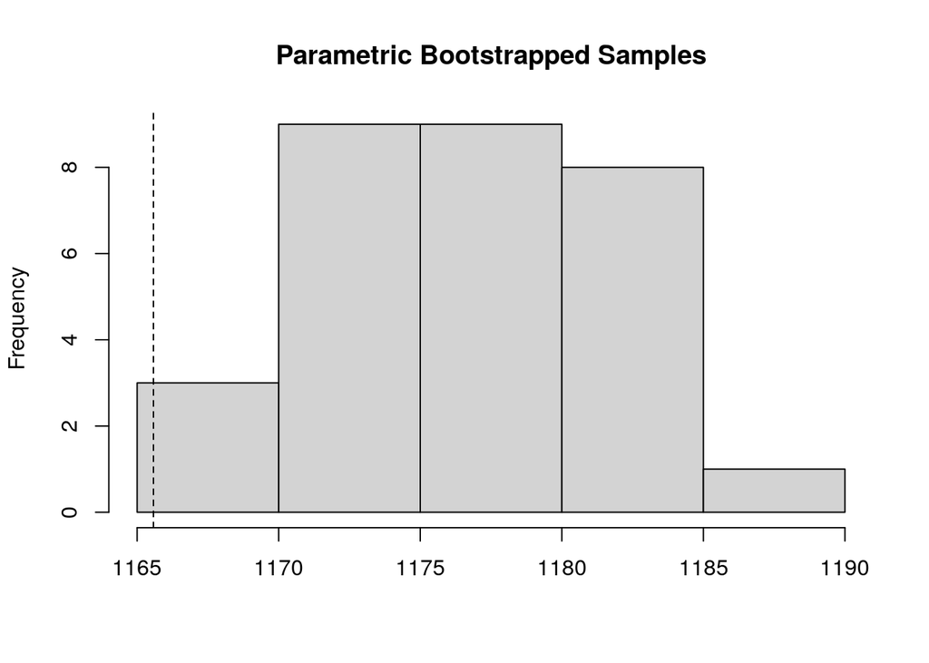

```r
gof;plot(gof)
```

H_0: le mod?le est adequat, vs H_1 : non H_0. pvalue > 0.05 -> On ne peut pas rejeter l’hypoth?se nulle ie on ne peut pas dire que le modele est inadequat. pvalue <0.05 -> On rejette l’hypothese nulle: Le modele n’est pas ad?quat.

(avec le changement, on accepte)

```r
mb_test <- suppressWarnings(AICcmodavg::mb.gof.test(fm, nsim=100))
```

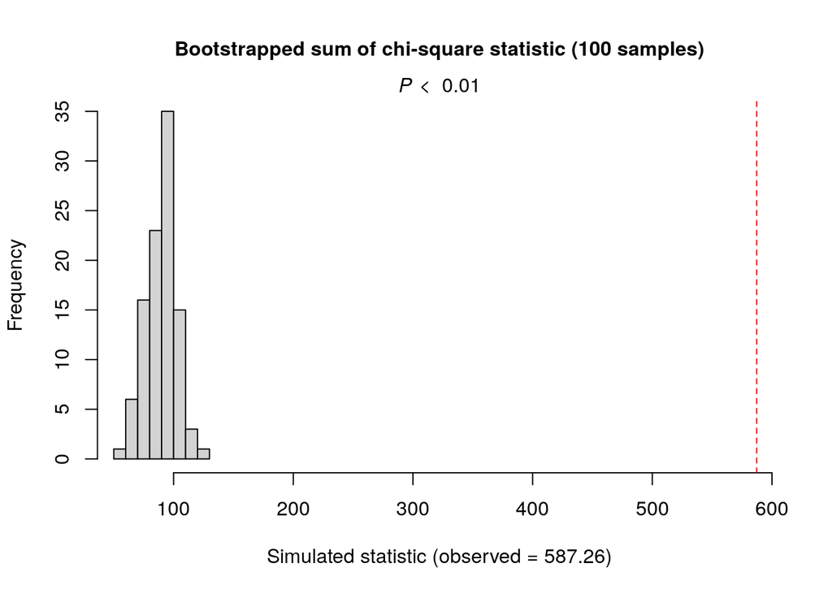

et ici on a un c-hat > 4 donc mauvais + p-value faible: on regette le modele.

```r
chisq <- function(fm) {
    umf <- fm@data
    y <- umf@y
    y[y>1] <- 1
    fv <- fitted(fm)
    sum((y-fv)^2/(fv*(1-fv)), na.rm=TRUE)
    }

set.seed(1)
(pb <- parboot(fm2, statistic=chisq, nsim=100, parallel=FALSE))
```

```
##
## Call: parboot(object = fm2, statistic = chisq, nsim = 100, parallel = FALSE)
##
## Parametric Bootstrap Statistics:
##     t0 mean(t0 - t_B) StdDev(t0 - t_B) Pr(t_B > t0)
## 1 4705          -50.5             7.63         0.99
##
## t_B quantiles:
##        0% 2.5%  25%  50%  75% 97.5% 100%
## [1,] 4739 4741 4750 4754 4760  4771 4777
##
## t0 = Original statistic computed from data
## t_B = Vector of bootstrap samples
```

LE LAPIN OKAY? Un peu suspicieux quand m?me 0.99 ….

```r
fm2 <- unmarked::colext(psiformula = ~Dnst_Cultures + Dist_Littoral +
    X_10km, gammaformula = ~1, epsilonformula = ~1, pformula = ~1,
    data = umf, se = TRUE, control = list(trace = 1))
```

## 8 Graphiques

```r
m1 <- nonparboot(fm,
                 B = 10)
```

[figure not shown]

```r
predicted_occupancy <- data.frame(saison = c(1:3),
                                  smoothed_occ = smoothed(fm)[2,],
                                  SE = m1@smoothed.mean.bsse[2,])

predicted_occupancy%>%
  ggplot( aes(x=saison, y=smoothed_occ)) +
  geom_line() +
  geom_point() +
  labs(title = "Probabilit? d'occupation du putois a travers les saisons")+
  theme_bw()
```

```r
grid_10x10 <- st_read(paste0(wd$data,
                             "derived/VariablesSite.shp")) %>%
  transforme_carte()
```

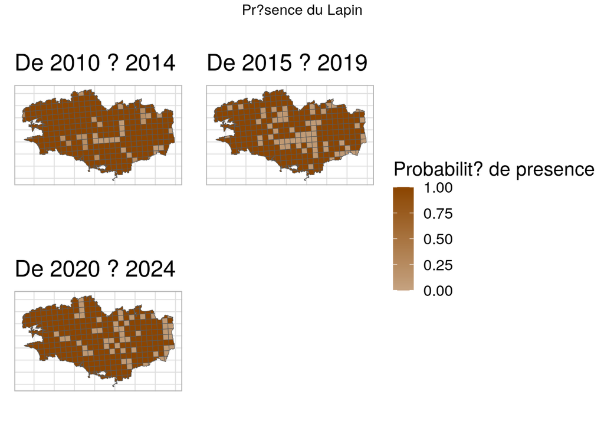

```r
rf <- unmarked::ranef(fm)
occ_prob <- unmarked::bup(rf, stat="mean")

grid_10x10 <- cbind(grid_10x10, occ_prob)


LtoM <-colorRampPalette(c('white','darkorange4'))


g1 <- ggplot() +
  geom_sf(data = grid_10x10, aes(fill = X1))+
  labs(title="De 2010 ? 2014")+
  scale_fill_gradient2(low=LtoM(0),
                       high=LtoM(100),
                       limits = c(0, 1),
                       name = "Probabilit? de presence")+
  theme(axis.text = element_blank(),
        axis.ticks = element_blank(),
        axis.title = element_blank())


g2 <- ggplot() +
  geom_sf(data = grid_10x10, aes(fill = X2))+
  labs(title="De 2015 ? 2019")+
  scale_fill_gradient2(low=LtoM(0),
                       high=LtoM(100),
                       limits = c(0, 1),
                       name = "Probabilit? de presence")+
  theme(axis.text = element_blank(),
        axis.ticks = element_blank(),
        axis.title = element_blank())


g3 <- ggplot() +
  geom_sf(data = grid_10x10, aes(fill = X3))+
  labs(title="De 2020 ? 2024")+
  scale_fill_gradient2(low=LtoM(0),
                       high=LtoM(100),
                       limits = c(0, 1),
                       name = "Probabilit? de presence")+
  theme(axis.text = element_blank(),
        axis.ticks = element_blank(),
        axis.title = element_blank())


plot <- ggpubr::ggarrange(g1 + theme(legend.position = "none"),
                          g2 + theme(legend.position = "none"),
                          g3 + theme(legend.position = "none"),
                          common.legend = TRUE,
                          legend = "right")

ggpubr::annotate_figure(plot,
                        top = ggpubr::text_grob("Pr?sence du Lapin"))
```